# EB3I n1 2025 scRNAseq - **PROCESSING (II)** - Dimension reduction & visualization

### 10.3.2 Cluster-specific markers

A practical way to characterize our clustering results is to get back to a level of knowledge you are confident in : marker genes.

Seurat has a handy function to :

- Identify differential expressed genes specific to each and every provided category of cells (here, clustering results)
- Draw a clusterized, annotated heatmap of these genes

**DEMO**

```r
?Seurat::FindAllMarkers
```

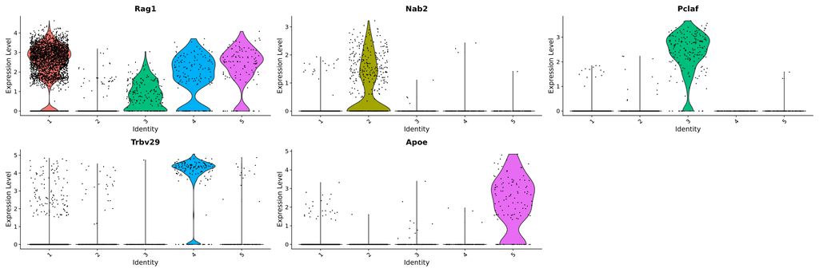

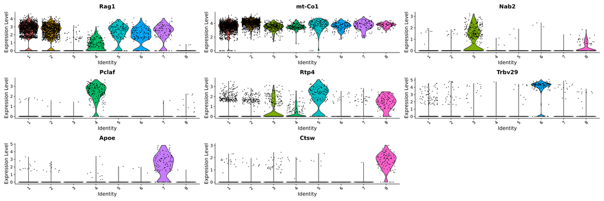

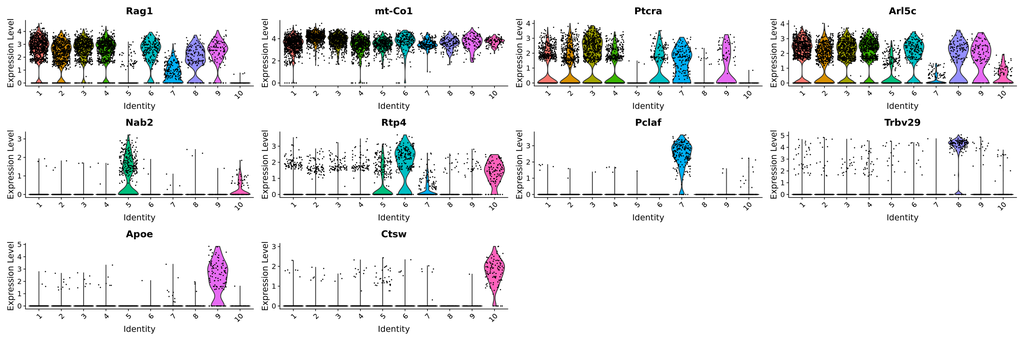

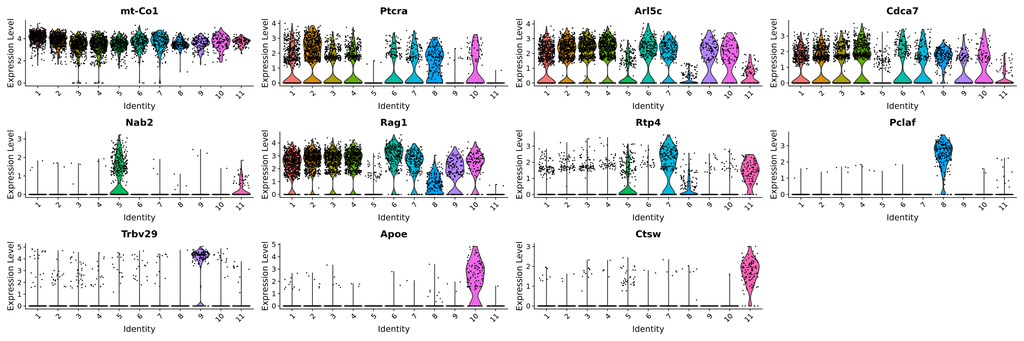

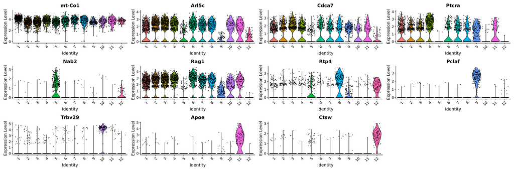

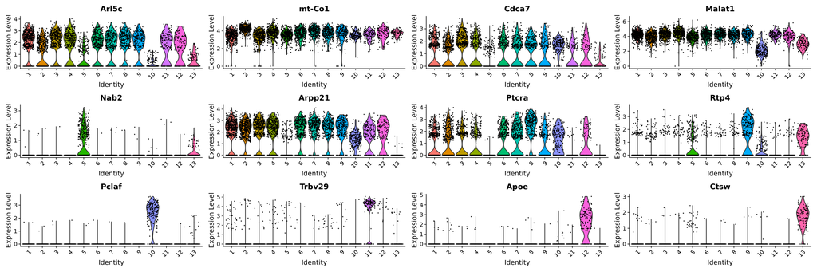

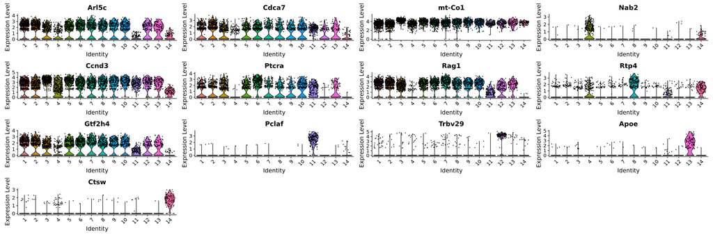

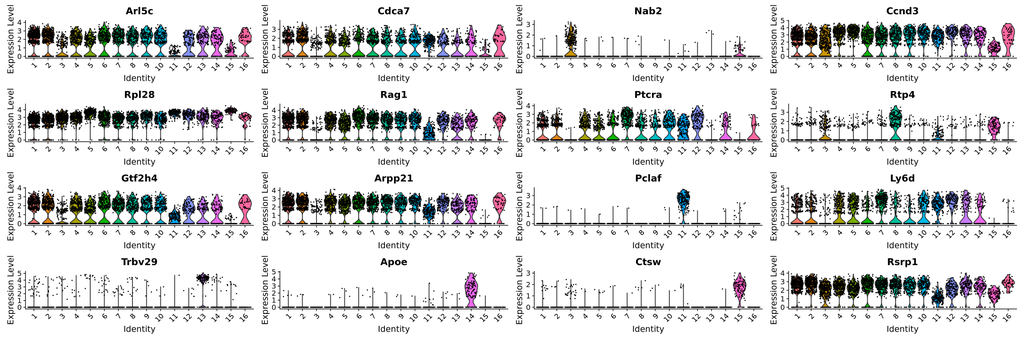

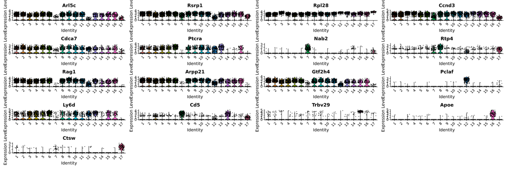

```r
# dhm_prep

## Looping on clustering results
fam_all <- lapply(resol_names, function(r) {

  ## Find markers for all clusters
  ## A seed is needed here !
  Seurat::Idents(object = sobj) <- sobj[[r]][[1]]
  fam <- Seurat::FindAllMarkers(
    object = sobj,
    logfc.threshold = .5,
    only.pos = TRUE,
    min.pct = .5,
    verbose = FALSE,
    random.seed = my_seed)

  ## Get top gene per cluster
  famtop <- fam$gene[!duplicated(fam$cluster)]
  vln_pl <- Seurat::VlnPlot(object = sobj, features = famtop)
  print(vln_pl)

  ## Select top10 genes when available
  fam_rdx <- dplyr::group_by(.data = fam, cluster)
  fam_rdx <- dplyr::filter(.data = fam_rdx, avg_log2FC > 1)
  fam_rdx <- dplyr::slice_head(.data = fam_rdx, n = 10)
  dh <- Seurat::DoHeatmap(
    object = sobj, features = fam_rdx$gene, size = 3,
    combine = TRUE) + ggplot2::ggtitle(label = r)
  return(dh)
})
```

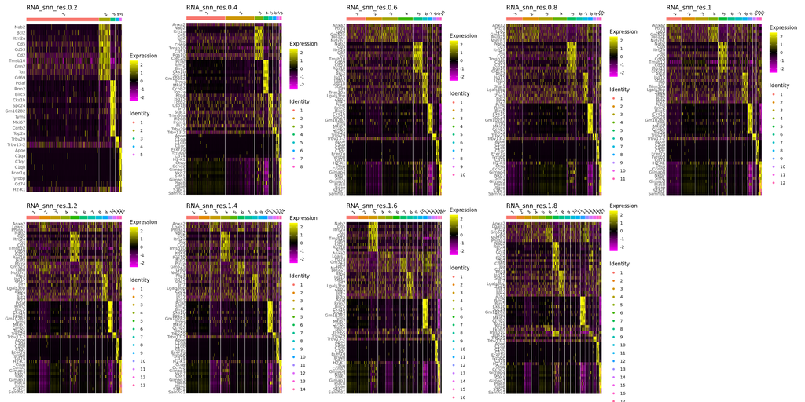

```r
# dhm_plot

## Plot all heatmaps at once
patchwork::wrap_plots(fam_all) + patchwork::plot_layout(nrow = 2)
```

**Questions** : Comparing the heatmaps :

**QUESTION 12**

Which resolution would you choose, and why ?

**QUESTION 13**

Is there a single one and only answer to the former question ?

### 10.3.3 Clusters contingencies and proportions

One can observe how many cells are in each cluster, and what proportion of all cells these represent (DEMO)

**DEMO**

```r
# clustpop

## Looping on resolutions
for (x in resol_names) {
  ## Contingencies
  print(table(sobj[[x]]))
  ## Proportions
  print(format(table(sobj[[x]]) / ncol(sobj), digits = 2))
  cat('\n\n')
}
```

```
RNA_snn_res.0.2
   1    2    3    4    5
3097  477  200  147  112
RNA_snn_res.0.2
      1       2       3       4       5
"0.768" "0.118" "0.050" "0.036" "0.028"


RNA_snn_res.0.4
   1    2    3    4    5    6    7    8
1668 1254  377  200  164  152  114  104
RNA_snn_res.0.4
      1       2       3       4       5       6       7       8
"0.414" "0.311" "0.093" "0.050" "0.041" "0.038" "0.028" "0.026"


RNA_snn_res.0.6
  1   2   3   4   5   6   7   8   9  10
830 699 669 650 401 214 200 152 114 104
RNA_snn_res.0.6
      1       2       3       4       5       6       7       8       9      10
"0.206" "0.173" "0.166" "0.161" "0.099" "0.053" "0.050" "0.038" "0.028" "0.026"


RNA_snn_res.0.8
  1   2   3   4   5   6   7   8   9  10  11
694 689 614 594 403 255 220 200 146 114 104
RNA_snn_res.0.8
      1       2       3       4       5       6       7       8       9      10
"0.172" "0.171" "0.152" "0.147" "0.100" "0.063" "0.055" "0.050" "0.036" "0.028"
     11
"0.026"


RNA_snn_res.1
  1   2   3   4   5   6   7   8   9  10  11  12
643 592 564 416 398 321 309 221 200 151 114 104
RNA_snn_res.1
      1       2       3       4       5       6       7       8       9      10
"0.159" "0.147" "0.140" "0.103" "0.099" "0.080" "0.077" "0.055" "0.050" "0.037"
```

[output cut: 27 more lines]

```
RNA_snn_res.1.6
      1       2       3       4       5       6       7       8       9      10
"0.129" "0.108" "0.099" "0.081" "0.079" "0.075" "0.074" "0.061" "0.052" "0.051"
     11      12      13      14      15      16
"0.050" "0.039" "0.036" "0.029" "0.026" "0.012"


RNA_snn_res.1.8
  1   2   3   4   5   6   7   8   9  10  11  12  13  14  15  16  17
445 324 312 302 298 291 278 248 237 211 207 200 160 157 142 115 106
RNA_snn_res.1.8
      1       2       3       4       5       6       7       8       9      10
"0.110" "0.080" "0.077" "0.075" "0.074" "0.072" "0.069" "0.061" "0.059" "0.052"
     11      12      13      14      15      16      17
"0.051" "0.050" "0.040" "0.039" "0.035" "0.029" "0.026"
```

## 10.4 Selection

For the downstream analyses, we will use the resolution **`0.6`**.

We will fix the clustering results for this resolution as the default one Seurat will use for any further analyses / plots, using the `Seurat::Idents()` function.

```r
# sel_res

## Fixing l_res
l_res <- .6

## Performing Leiden clustering at the selected resolution
sobj <- Seurat::FindClusters(
  object = sobj,
  resolution = l_res,
  algorithm = 4,
  random.seed = my_seed,
  verbose = FALSE)

## Check on default "Idents"
identical(
  x = SeuratObject::FetchData(
    object = sobj,
    vars = paste0("RNA_snn_res.", l_res))[[1]],
  y = unname(Seurat::Idents(object = sobj))
)
```

```
[1] TRUE
```

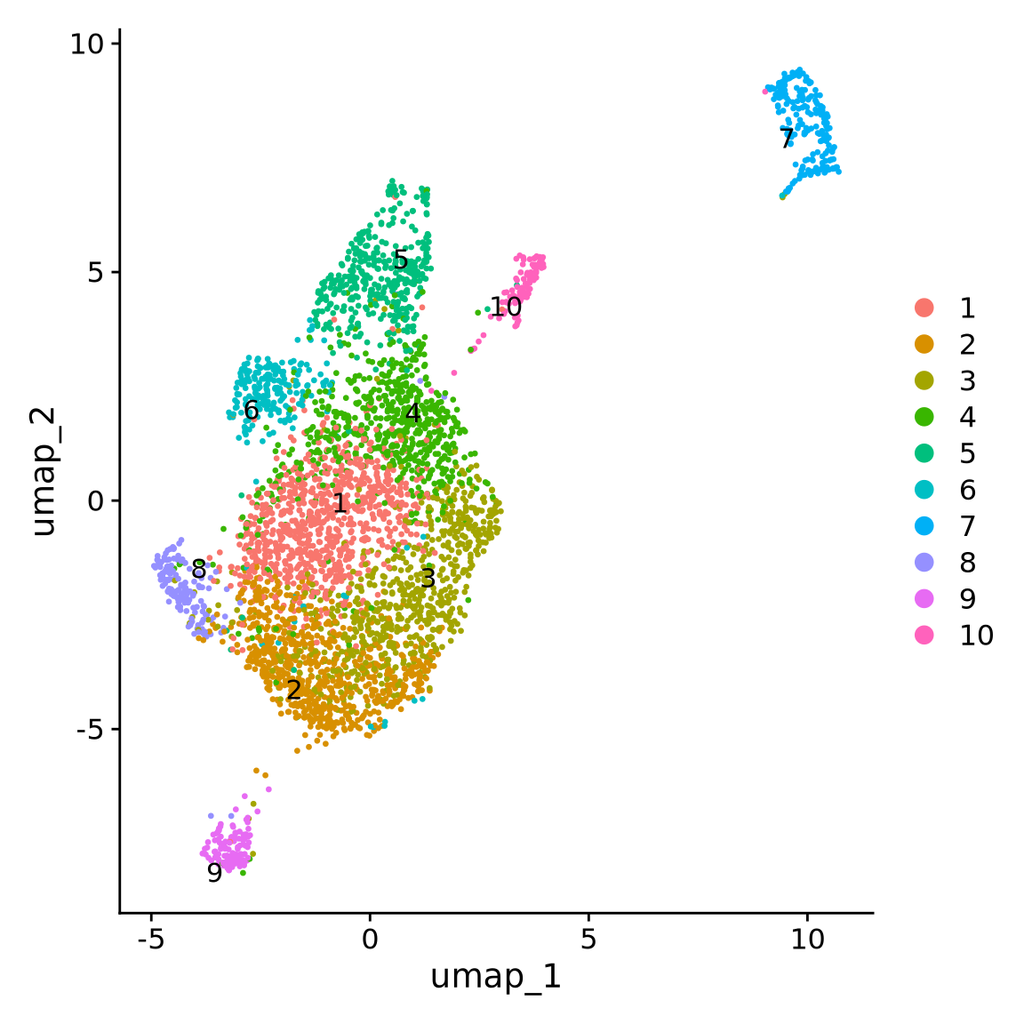

```r
## DimPlot without specifying the resolution
Seurat::DimPlot(
  object = sobj,
  reduction = "umap",
  label = TRUE,
  repel = TRUE)
```

# 11 Save the Seurat object

We will save our Seurat object that now contains our clustering results :

```r
# saverds2

## Save our Seurat object (rich naming)
save_step(
  object = sobj,
  step_number = 10,
  step_name = paste0("Clustered.", l_res),
  output_dir = output_dir
)
```

```
Saved [/shared/projects/ebaii_sc_teachers/SC_TD/05_Proc.2/RESULTS/10_TD3A_S5_Clustered.0.6_12508.4033.RDS]
```

# 12 Rsession

**DEMO**